[figure not shown]

[figure not shown]

# En qué consiste la Propuesta

La Ciencia de Datos es un área de estudio donde la estadística, las matemáticas y la programación se aprenden en conjunto. Se tuvieron tres sesiones de capacitación a manera de introducción a la carrera donde aprendimos tres esquemas generales de modelado de datos. Estos corresponden a una forma de organizar, clasificar e identificar datos de los modelos conocidos hasta el momento de Machine Learning o Inteligencia Artificial .

Es entonces que hablamos del aprendizaje del entrenamiento supervisado donde se conocen variables de salida que se quieren estimar para predecir resultados. Aquí vimos regresión. lineal y la clasificación de datos. Es aquí donde contemplamos la cantidad de los valores, su peso y como este impacta en el modelado de datos para brindar un resultado.

Los temas visto hasta cierto punto fueron, Regresión Lineal, Clasificación y Clustering, y en base a ellos es que genero la siguiente propuesta: La Huella Que Dejamos. Donde voy a abordar el tema de el Medio Ambiente y como este se impacta la mala calidad del aire y su relación con la movilidad urbana en la huella de carbono.

Por lo que los conocimientos que obtuve, más los conocimientos que ya tenía, plantearé una forma de resolverlo teniendo con una regresión lineal en R tomando en cuenta como valores, la calidad de aire y la movilidad durante el año 2020, donde comenzó la pandemia.

**Bajo la siguiente hipótesis: A mayor cantidad de gente en su casa: menor cantidad de emisiones atmosféricas (especialmente NOX) y mayor cantidad de generación de O3 troposférico.**

Esto es lo que se va a contemplar para este proyecto:

**NOX y Ozono** (adjunto imagen para ver las consecuencias del NOX)

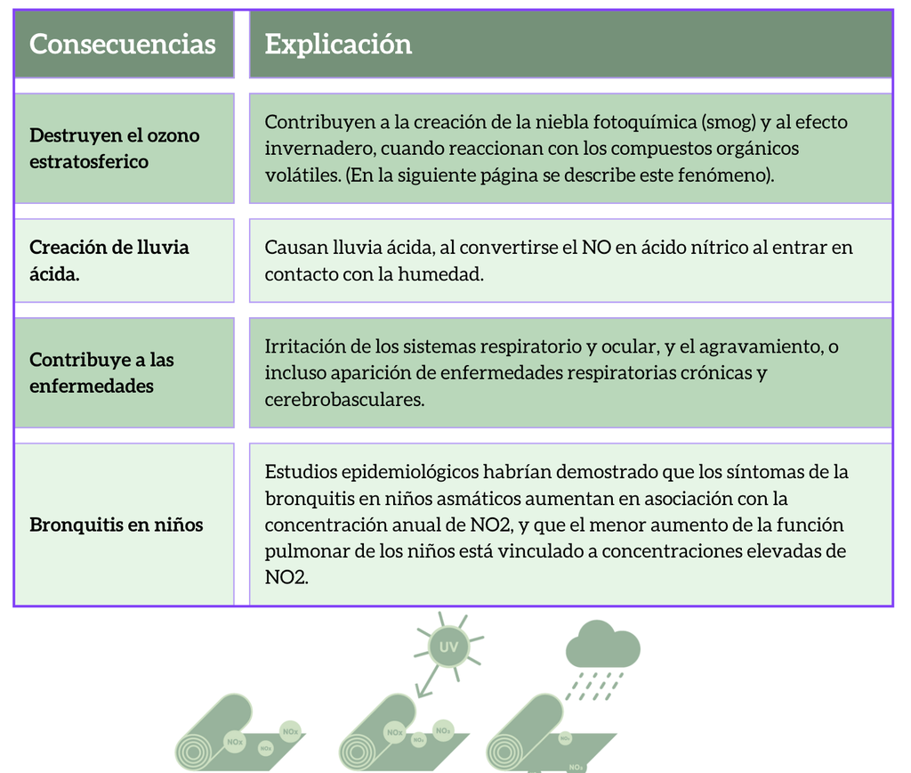

**Movilidad urbana** (adjunto imagen para explicar los tipos) Imagen de los tipos de movilidad

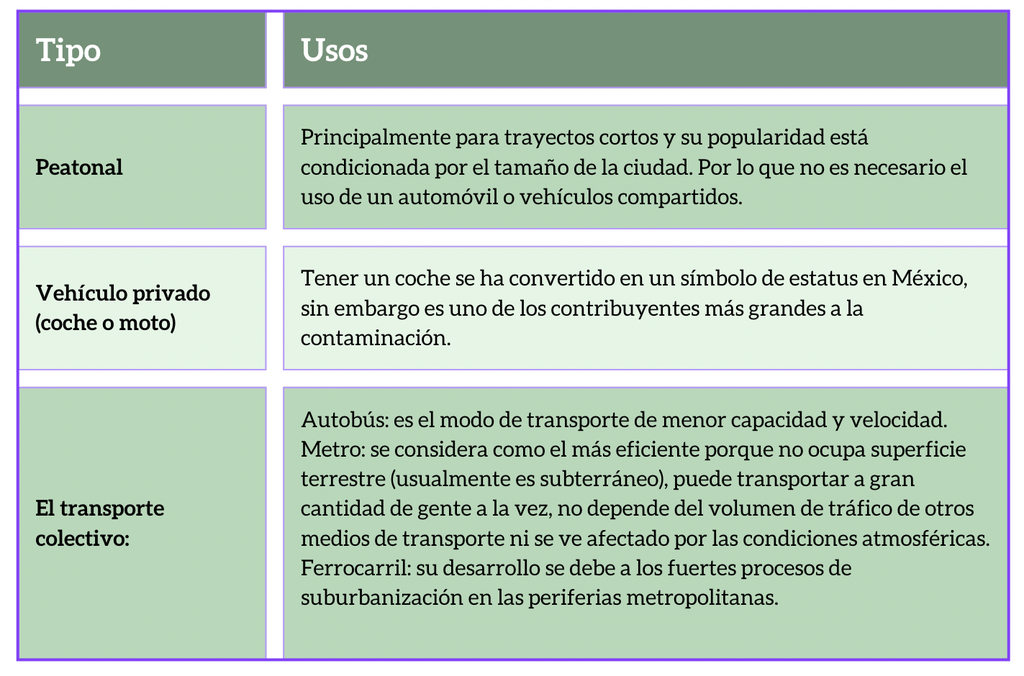

Y se tomará en cuenta para explicar la relación entre estos componentes con la **regresión lineal** que consiste en predecir por medio de definir variables, el valor de otra. La variable que está utilizando para predecir el valor de la otra variable se denomina variable independiente. Esta forma de análisis estima los coeficientes de la ecuación lineal, involucrando una o a más variables independientes que mejor predicen el valor de la variable dependiente.

# Datos de O3 y NOx

### Ozono

[interactive chart not shown]

### NOx

[interactive chart not shown]

### Tabla de datos

| fecha | ozono | nox | residencial | trabajo |
| --- | --- | --- | --- | --- |
| 2020-01-01 | 0.0112083 | 0.0106429 | NA | NA |
| 2020-01-02 | 0.0194167 | 0.0124286 | NA | NA |
| 2020-01-03 | 0.0152500 | 0.0416364 | NA | NA |
| 2020-01-04 | 0.0195000 | 0.0322609 | NA | NA |
| 2020-01-05 | 0.0228750 | 0.0292778 | NA | NA |
| 2020-01-06 | 0.0247917 | 0.0506667 | NA | NA |
| 2020-01-07 | 0.0171250 | 0.0626522 | NA | NA |
| 2020-01-08 | 0.0224167 | 0.0398421 | NA | NA |
| 2020-01-09 | 0.0218333 | 0.0323333 | NA | NA |
| 2020-01-10 | 0.0142917 | 0.0268947 | NA | NA |
| 2020-01-11 | 0.0195000 | 0.0424762 | NA | NA |
| 2020-01-12 | 0.0210833 | 0.0396250 | NA | NA |
| 2020-01-13 | 0.0190417 | 0.0453636 | NA | NA |
| 2020-01-14 | 0.0286667 | 0.0515333 | NA | NA |
| 2020-01-15 | 0.0314167 | 0.0484118 | NA | NA |
| 2020-01-16 | 0.0281667 | 0.0387647 | NA | NA |
| 2020-01-17 | 0.0287917 | 0.0275000 | NA | NA |
| 2020-01-18 | 0.0188333 | 0.0352778 | NA | NA |
| 2020-01-19 | 0.0197500 | 0.0214783 | NA | NA |
| 2020-01-20 | 0.0175833 | 0.0326000 | NA | NA |
| 2020-01-21 | 0.0210000 | 0.0297778 | NA | NA |
| 2020-01-22 | 0.0215000 | 0.0340000 | NA | NA |
| 2020-01-23 | 0.0148333 | 0.0250000 | NA | NA |
| 2020-01-24 | 0.0184583 | 0.0392941 | NA | NA |
| 2020-01-25 | 0.0188333 | 0.0118000 | NA | NA |
| 2020-01-26 | 0.0165417 | 0.0164444 | NA | NA |
| 2020-01-27 | 0.0187917 | 0.0335333 | NA | NA |
| 2020-01-28 | 0.0203333 | 0.0406111 | NA | NA |
| 2020-01-29 | 0.0224167 | 0.0323750 | NA | NA |
| 2020-01-30 | 0.0249167 | 0.0096154 | NA | NA |

[output cut: 336 more lines]

# Reporte de movilidad

Este es un gráfico que muestra la permanencia de personas en su casa “residential” Movilidad urbana: el conjunto de desplazamientos, tanto de personas como de mercancías, que se producen en una ciudad, bien sea en transporte público o privado." **Estos al momento de desplazarse con vehículos que usan combustibles fósiles para el motor, emiten gases que son perjudiciales a la calidad del aire.** Aquí podemos ver que durante inicios de la pandemia la mayoría se quedó en sus casas y la movilidad laboral se redujo.

[interactive chart not shown]

## Gente que se mueve a su trabajo

[interactive chart not shown]

# Regresión lineal cont

Gráfica de regresión

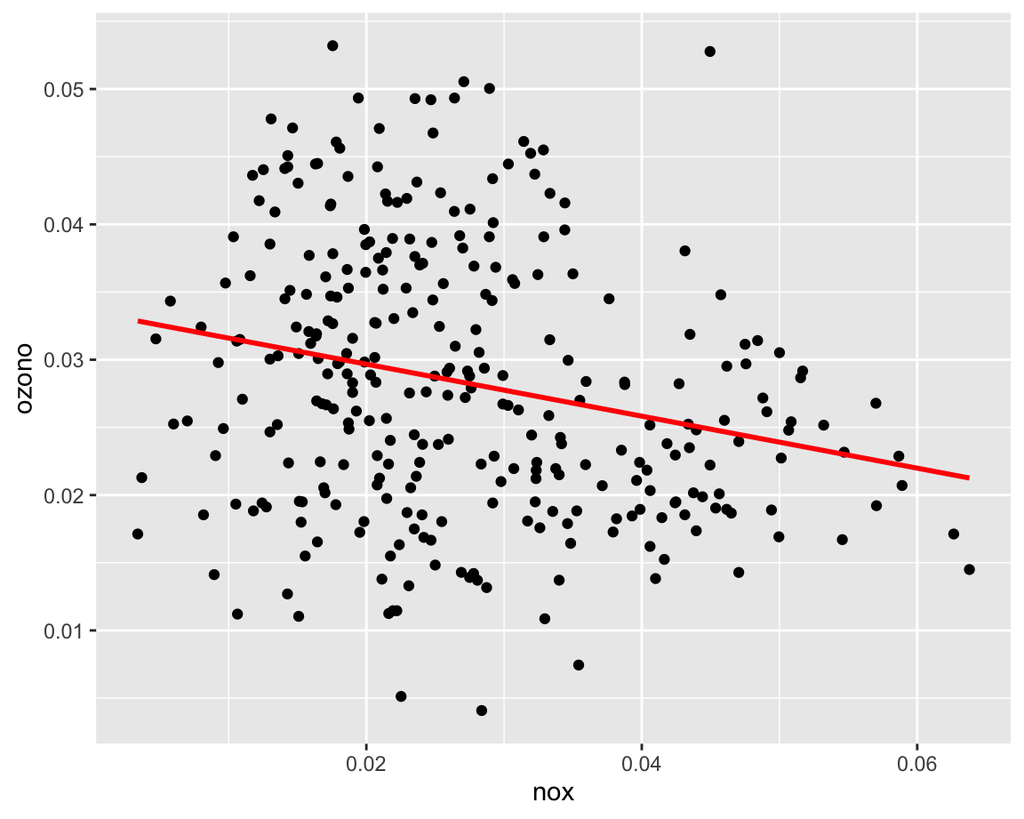

Resumen del modelo

[output not shown]

# Regresión lineal movilidad

Gráfica de regresión

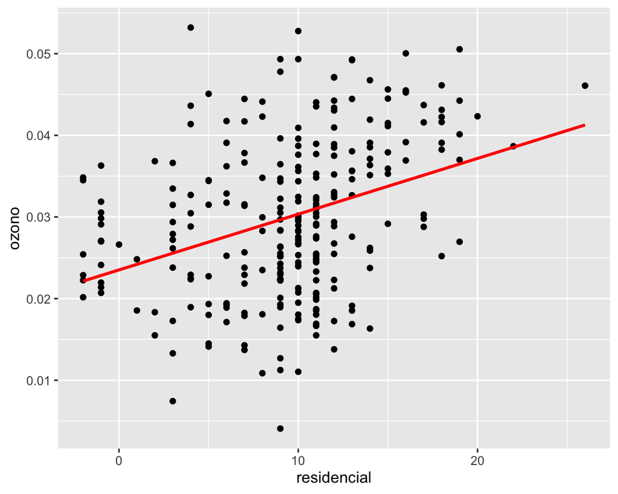

Resumen del modelo

```
Call:
lm(formula = ozono ~ residencial, data = datos2)

Residuals:
       Min         1Q     Median         3Q        Max
-0.0255770 -0.0064731  0.0001285  0.0063537  0.0269542

Coefficients:
             Estimate Std. Error t value Pr(>|t|)
(Intercept) 0.0235142  0.0012061  19.496  < 2e-16 ***
residencial 0.0006829  0.0001135   6.015 6.04e-09 ***
---
Signif. codes:  0 '***' 0.001 '**' 0.01 '*' 0.05 '.' 0.1 ' ' 1

Residual standard error: 0.009089 on 261 degrees of freedom
Multiple R-squared:  0.1218,    Adjusted R-squared:  0.1184
F-statistic: 36.18 on 1 and 261 DF,  p-value: 6.043e-09
```

# Datos de Calidad del aire

El **ozono** (O3) es una molécula compuesta por tres átomos de oxígeno. Es un gas incoloro e inestable que se encuentra en la atmósfera terrestre. A nivel del suelo, el ozono es considerado un contaminante peligroso para la salud humana y el medio ambiente.

Los **óxidos de nitrógeno** (NOx) son un grupo de gases compuestos por óxido nítrico (NO) y dióxido de nitrógeno (NO2). Estos gases son producidos principalmente por la combustión de combustibles fósiles en vehículos y plantas industriales. Los NOx son contaminantes peligrosos para la salud humana y el medio ambiente.

Ubicación de la estación de calidad del aire de la cual se tomaron los datos:

[interactive chart not shown]